# Environmental Enforcement as a Credit Allocation Mechanism

- Show All Code
- Hide All Code
- View Source

A Staggered Difference-in-Differences Analysis

Author

Josefina Silva Fuentealba

Published

May 1, 2026

# 1 Data Cleaning

## 1.1 CMF Credit Registry

The CMF credit registry (`cmf_project_2011-2024.dta`) contains the universe of corporate loans issued by Chilean banks. We keep only firms matched with the SII tax registry (`mergeC11D03 == 3`), construct the **new-credit variable** as the positive first difference in outstanding loan balances at the bank–firm–month level, and collapse to annual frequency.

```r
# ── 1. Load ───────────────────────────────────────────────────────────────────
cmf_raw <- read_dta(din("Base Final/cmf_project_2011-2024.dta"))

# ── 2. Keep matched firms only ────────────────────────────────────────────────
cmf <- cmf_raw |>
  filter(mergeC11D03 == 3, c11_cartera_normal > 0) |>
  select(-mergeC11D03)

# ── 3. Parse year from periodo (YYYYMM) ───────────────────────────────────────
cmf <- cmf |>
  mutate(year = as.integer(substr(as.character(periodo), 1, 4)))

# ── 4. Build bank-firm-year NEW CREDIT flow ───────────────────────────────────
# New credit is the positive monthly change in outstanding balance.
cmf_annual <- cmf |>
  group_by(id, ins_cod) |>
  arrange(periodo, .by_group = TRUE) |>
  mutate(
    newcred_cartera = pmax(c11_cartera_normal - lag(c11_cartera_normal), 0),
    newcred_cartera = replace_na(newcred_cartera, 0)
  ) |>
  ungroup() |>
  group_by(id, ins_cod, year, región, subrubroeconómico) |>
  summarise(
    newcred_cartera = sum(newcred_cartera,         na.rm = TRUE),
    avg_colat       = mean(c11_deducido_expos_garanreal +
                           c11_deducido_expos_garfinanc, na.rm = TRUE),
    avg_cat         = mean(d03_cat_deudor,         na.rm = TRUE),
    .groups         = "drop"
  ) |>
  mutate(
    # log1p para incluir ceros
    lnewcred = log1p(newcred_cartera)
  )

cat("Annual panel (new credit flow):\n")
```

```
Annual panel (new credit flow):
```

```r
cat("  Obs:          ", nrow(cmf_annual), "\n")
```

```
  Obs:           851719
```

```r
cat("  Unique pairs: ", n_distinct(paste(cmf_annual$id, cmf_annual$ins_cod)), "\n")
```

```
  Unique pairs:  188292
```

```r
cat("  Years:        ", paste(range(cmf_annual$year), collapse = "-"), "\n")
```

```
  Years:         2011-2024
```

## 1.2 Regional IDs and Court Entry Dates

We assign numeric region IDs and code the staggered court entry year (`year_court`). Three environmental courts were established under Law No. 20,600:

| Court | Regions | Entry year |
| --- | --- | --- |
| Santiago | 5, 6, 7, 13, 16 | 2013 |
| Valdivia | 8, 9, 10, 11, 12, 14 | 2014 |
| Antofagasta | 1, 2, 3, 4, 15 | 2017 |

```r
region_lookup <- tribble(
  ~región,                                                          ~regid,
  "I REGION DE TARAPACA",                                              1L,
  "II REGION DE ANTOFAGASTA",                                          2L,
  "III REGION DE ATACAMA",                                             3L,
  "IV REGION COQUIMBO",                                                4L,
  "V REGION VALPARAISO",                                               5L,
  "VI REGION DEL LIBERTADOR GENERAL BERNARDO O'HIGGINS",               6L,
  "VII REGION DEL MAULE",                                              7L,
  "VIII REGION DEL BIO BIO",                                           8L,
  "IX REGION DE LA ARAUCANIA",                                         9L,
  "X REGION LOS LAGOS",                                               10L,
  "XI REGION AYSEN DEL GENERAL CARLOS IBAÑEZ DEL CAMPO",             11L,
  "XII REGION DE MAGALLANES Y LA ANTARTICA CHILENA",                  12L,
  "XIII REGION METROPOLITANA",                                        13L,
  "XIV REGION DE LOS RIOS",                                           14L,
  "XV REGION ARICA Y PARINACOTA",                                     15L,
  "XVI REGION DE ÑUBLE",                                              16L
)

court_lookup <- tribble(
  ~regid, ~year_court,
  # Santiago court — January 2013
   5L, 2013L,  6L, 2013L,  7L, 2013L, 13L, 2013L, 16L, 2013L,
  # Valdivia court — December 2013 (first full year = 2014)
   8L, 2014L,  9L, 2014L, 10L, 2014L, 11L, 2014L, 12L, 2014L, 14L, 2014L,
  # Antofagasta court — July 2017
   1L, 2017L,  2L, 2017L,  3L, 2017L,  4L, 2017L, 15L, 2017L
)

cmf_annual <- cmf_annual |>
  left_join(region_lookup, by = "región") |>
  left_join(court_lookup,  by = "regid") |>
  mutate(
    # never-treated = 0 (required by the did package)
    year_court = replace_na(year_court, 0L),
    court      = as.integer(year_court > 0 & year >= year_court)
  )
```

## 1.3 SMA Enforcement Cases

```r
sma_raw <- read_dta(din("cmf_project_super_intendencia.dta")) |>
  mutate(year = as.integer(year))  # viene como string, hay que convertir

# Construir regid desde region (string) usando el mismo lookup de arriba
region_lookup_sma <- tribble(
  ~region,                                                              ~regid,
  "Región de Tarapacá",                                                     1L,
  "Región de Antofagasta",                                                   2L,
  "Región de Atacama",                                                       3L,
  "Región de Coquimbo",                                                      4L,
  "Región de Valparaíso",                                                    5L,
  "Región del Libertador General Bernardo O'Higgins",                        6L,
  "Región del Maule",                                                        7L,
  "Región del Biobío",                                                       8L,
  "Región de la Araucanía",                                                  9L,
  "Región de los Lagos",                                                    10L,
  "Región de Aysén del General Carlos Ibáñez del Campo",                   11L,
  "Región de Magallanes y la Antártica Chilena",                           12L,
  "Región Metropolitana",                                                   13L,
  "Región de Los Ríos",                                                     14L,
  "Región de Arica y Parinacota",                                           15L,
  "Región de Ñuble",                                                        16L
)

# Contar casos por region-year y calcular lrcases (lag log)
reg_cases <- sma_raw |>
  left_join(region_lookup_sma, by = "region") |>
  filter(!is.na(regid)) |>
  group_by(regid, year) |>
  summarise(cases = n(), .groups = "drop") |>
  arrange(regid, year) |>
  group_by(regid) |>
  mutate(lrcases = lag(log1p(cases))) |>   # one-year lag, as in paper
  ungroup()

# Merge into annual panel
cmf_annual <- cmf_annual |>
  left_join(reg_cases |> select(regid, year, lrcases),
            by = c("regid", "year")) |>
  mutate(lrcases = replace_na(lrcases, 0))

cat("SMA cases merged. Regions covered:", n_distinct(reg_cases$regid), "\n")
```

```
SMA cases merged. Regions covered: 16
```

```r
cat("Years covered:", paste(range(reg_cases$year, na.rm = TRUE), collapse = "-"), "\n")
```

```
Years covered: 2013-2024
```

## 1.4 ENCORE Environmental Impact Scores

```r
# super_IDs.dta is already built by your Stata pipeline (CR_WDD_mob.do)
encore <- read_dta(din("super_IDs.dta")) |>
  select(subrubroeconómico, score_share, d50_score, d75_score) |>
  mutate(subrubroeconómico = str_trim(subrubroeconómico))

cmf_annual <- cmf_annual |>
  mutate(subrubroeconómico = str_trim(subrubroeconómico)) |>
  left_join(encore, by = "subrubroeconómico")
```

## 1.5 Final Working Sample

```r
df <- cmf_annual |>
  filter(!is.na(regid), !is.na(score_share)) |>
  filter(regid != 13) |>
  mutate(
    lnewcred_w  = Winsorize(lnewcred,
                            quantile(lnewcred, probs = c(0.01, 0.99),
                                     na.rm = TRUE)),
    bankfirm_id = as.integer(interaction(ins_cod, id, drop = TRUE)),
    IDB         = as.integer(factor(ins_cod)),
    IDR         = as.integer(factor(regid)),
    IDS         = as.integer(factor(subrubroeconómico))
  )

cat("Final sample (new credit flow):\n")
```

```
Final sample (new credit flow):
```

```r
cat("  Obs:             ", nrow(df), "\n")
```

```
  Obs:              474785
```

```r
cat("  Bank-firm pairs: ", n_distinct(df$bankfirm_id), "\n")
```

```
  Bank-firm pairs:  104770
```

```r
cat("  Unique firms:    ", n_distinct(df$id), "\n")
```

```
  Unique firms:     59673
```

```r
cat("  Years:           ", paste(range(df$year), collapse = "-"), "\n")
```

```
  Years:            2011-2024
```

```r
cat("  Regions:         ", n_distinct(df$regid), "\n\n")
```

```
  Regions:          15
```

```r
# Balance del panel — clave para decidir si CS es viable
df |>
  group_by(bankfirm_id) |>
  summarise(n_years = n_distinct(year), .groups = "drop") |>
  count(n_years, name = "pairs") |>
  mutate(pct = round(100 * pairs / sum(pairs), 1)) |>
  print(n = 14)
```

```
# A tibble: 14 × 3
   n_years pairs   pct
     <int> <int> <dbl>
 1       1 14493  13.8
 2       2 18524  17.7
 3       3 15288  14.6
 4       4 15444  14.7
 5       5 12668  12.1
 6       6  6079   5.8
 7       7  4605   4.4
 8       8  3918   3.7
 9       9  4758   4.5
10      10  2125   2
11      11  1383   1.3
12      12  1316   1.3
13      13  1232   1.2
14      14  2937   2.8
```

```r
# ── Define never-treated following the paper's approach ───────────────────────
# Firms in sectors with score_share < 0.2 are assigned year_court = 0
# (never-treated) because environmental courts are unlikely to affect
# sectors with negligible environmental impact.
df <- df |>
  mutate(
    year_court = if_else(score_share < 0.2, 0L, year_court),
    court      = if_else(score_share < 0.2, 0L, court)
  )

# ── Fix: year_court must be time-invariant per bankfirm_id ────────────────────
# Some pairs change region or score_share across years (~2% of sample).
# We assign the modal (most frequent) year_court value per pair.
year_court_fixed <- df |>
  group_by(bankfirm_id) |>
  summarise(
    year_court = as.integer(names(which.max(table(year_court)))),
    .groups = "drop"
  )

df <- df |>
  select(-year_court) |>
  left_join(year_court_fixed, by = "bankfirm_id")

# ── Verify cohort distribution ─────────────────────────────────────────────────
cat("Cohort distribution after never-treated assignment:\n")
```

```
Cohort distribution after never-treated assignment:
```

```r
df |> distinct(bankfirm_id, year_court) |> count(year_court) |> print()
```

```
# A tibble: 4 × 2
  year_court     n
       <int> <int>
1          0 17535
2       2013 32010
3       2014 38564
4       2017 16661
```

```r
cat("\nNot-yet-treated + never-treated by year:\n")
```

```
Not-yet-treated + never-treated by year:
```

```r
df |>
  mutate(nyt = as.integer(year < year_court | year_court == 0)) |>
  group_by(year) |>
  summarise(
    treated     = sum(court == 1),
    control     = sum(nyt == 1),
    pct_control = round(100 * mean(nyt == 1), 1),
    .groups     = "drop"
  ) |>
  print(n = 14)
```

```
# A tibble: 14 × 4
    year treated control pct_control
   <int>   <int>   <int>       <dbl>
 1  2011       0   29412       100
 2  2012       0   31965       100
 3  2013    9410   24057        71.8
 4  2014   22041   12388        35.9
 5  2015   19654   11059        36.2
 6  2016   21601   11882        35.6
 7  2017   26527    6749        20.4
 8  2018   27469    6843        20
 9  2019   27692    6725        19.6
10  2020   28550    6459        18.6
11  2021   30328    6429        17.6
12  2022   32455    6600        17
13  2023   33192    6578        16.6
14  2024   25300    5083        16.8
```

```r
# ── Build df_cs ready for Callaway-Sant'Anna ───────────────────────────────────
df_cs <- df |>
  filter(!is.na(lnewcred_w), !is.na(lrcases), !is.na(score_share)) |>
  mutate(year_court = as.integer(year_court))

# Final check: no pair should have more than one year_court value
inconsistent <- df_cs |>
  group_by(bankfirm_id) |>
  summarise(n_values = n_distinct(year_court), .groups = "drop") |>
  filter(n_values > 1) |>
  nrow()

cat("\nPares con year_court inconsistente después del fix:", inconsistent, "\n")
```

```
Pares con year_court inconsistente después del fix: 0
```

```r
cat("df_cs listo para CS —", nrow(df_cs), "obs |",
    n_distinct(df_cs$bankfirm_id), "bank-firm pairs\n")
```

```
df_cs listo para CS — 474785 obs | 104770 bank-firm pairs
```

# 2 Descriptive Statistics

## 2.1 Summary Table

```r
vars_summary <- df |>
  select(
    `Log new credit (winsorised)` = lnewcred_w,
    `Log SMA cases (lag)`         = lrcases,
    `ENCORE score`                = score_share,
    `Court (binary)`              = court
  )

datasummary_skim(
  vars_summary,
  title  = "Table 1: Summary Statistics",
  notes  = "Sample: bank-firm-year observations 2011-2024. Santiago excluded.",
  output = "kableExtra"
) |>
  kable_styling(bootstrap_options = c("striped", "hover"), full_width = FALSE)
```

|  | Unique | Missing Pct. | Mean | SD | Min | Median | Max |
| --- | --- | --- | --- | --- | --- | --- | --- |
| Log new credit (winsorised) | 352250 | 0 | 12.1 | 6.5 | 0.0 | 14.2 | 21.2 |
| Log SMA cases (lag) | 132 | 0 | 4.2 | 2.2 | 0.0 | 4.9 | 7.2 |
| ENCORE score | 22 | 0 | 0.4 | 0.2 | 0.2 | 0.4 | 0.8 |
| Court (binary) | 2 | 0 | 0.6 | 0.5 | 0.0 | 1.0 | 1.0 |

## 2.2 New Credit Over Time by ENCORE Group

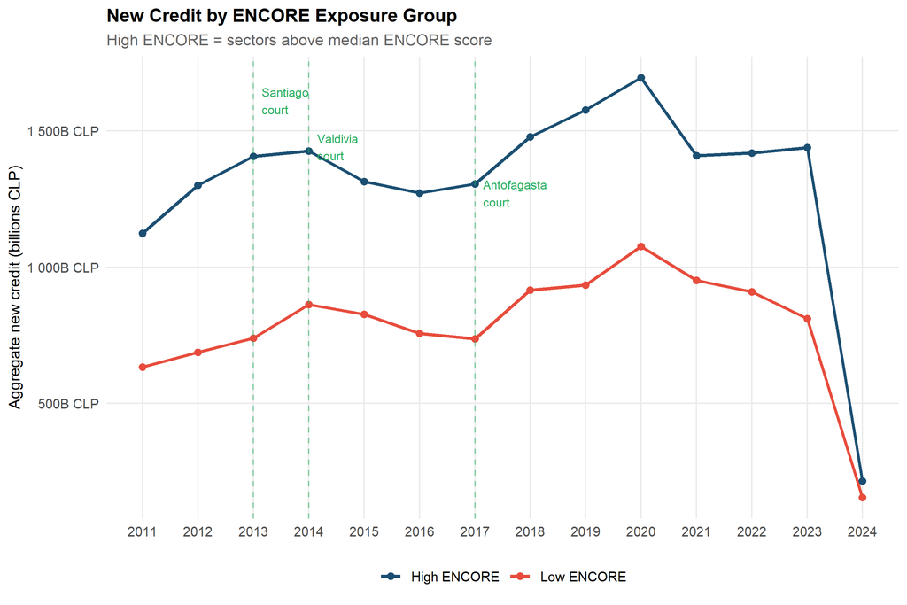

Aggregate new credit by ENCORE exposure group (2011-2024). Dashed lines mark court introduction years.

```r
credit_ts <- df |>
  filter(!is.na(d50_score)) |>
  group_by(year, d50_score) |>
  summarise(total = sum(exp(lnewcred_w), na.rm = TRUE) / 1e9, .groups = "drop") |>
  mutate(group = if_else(d50_score == 1, "High ENCORE", "Low ENCORE"))

ymax <- max(credit_ts$total, na.rm = TRUE)

ggplot(credit_ts, aes(year, total, colour = group)) +
  geom_line(linewidth = 1.1) +
  geom_point(size = 2) +
  geom_vline(xintercept = c(2013, 2014, 2017),
             linetype = "dashed", alpha = 0.5, colour = col_court) +
  annotate("text", x = c(2013.15, 2014.15, 2017.15),
           y = ymax * c(0.95, 0.85, 0.75),
           label = c("Santiago\ncourt", "Valdivia\ncourt", "Antofagasta\ncourt"),
           size = 3, hjust = 0, colour = col_court) +
  scale_colour_manual(values = c(col_high, col_low)) +
  scale_y_continuous(labels = label_number(suffix = "B CLP")) +
  scale_x_continuous(breaks = 2011:2024) +
  labs(
    title    = "New Credit by ENCORE Exposure Group",
    subtitle = "High ENCORE = sectors above median ENCORE score",
    x = NULL, y = "Aggregate new credit (billions CLP)",
    colour = NULL
  )
```

```r
ggsave(dout("fig1_credit_by_encore.png"), width = 9, height = 6, dpi = 150)
```

## 2.3 SMA Enforcement Activity

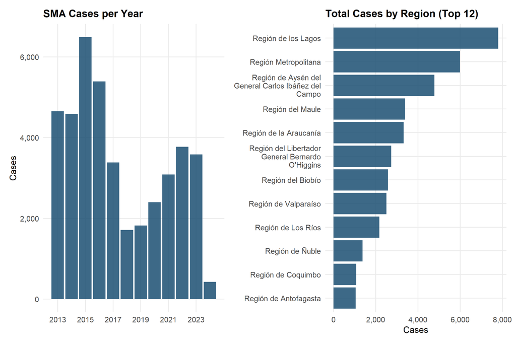

Left: total SMA cases per year. Right: cumulative cases by region.

```r
p1 <- sma_raw |>
  count(year) |>
  filter(year >= 2011) |>
  ggplot(aes(year, n)) +
  geom_col(fill = col_high, alpha = 0.85) +
  scale_y_continuous(labels = comma) +
  scale_x_continuous(breaks = seq(2011, 2024, 2)) +
  labs(title = "SMA Cases per Year", x = NULL, y = "Cases")

p2 <- sma_raw |>
  count(region, name = "cases") |>
  slice_max(cases, n = 12) |>
  mutate(region = str_wrap(region, 25),
         region = fct_reorder(region, cases)) |>
  ggplot(aes(cases, region)) +
  geom_col(fill = col_high, alpha = 0.85) +
  scale_x_continuous(labels = comma) +
  labs(title = "Total Cases by Region (Top 12)", x = "Cases", y = NULL)

p_sma <- p1 + p2
p_sma
```

```r
ggsave(dout("fig2_sma_activity.png"), plot = p_sma, width = 9, height = 5, dpi = 150)
```

## 2.4 ENCORE Score Distribution

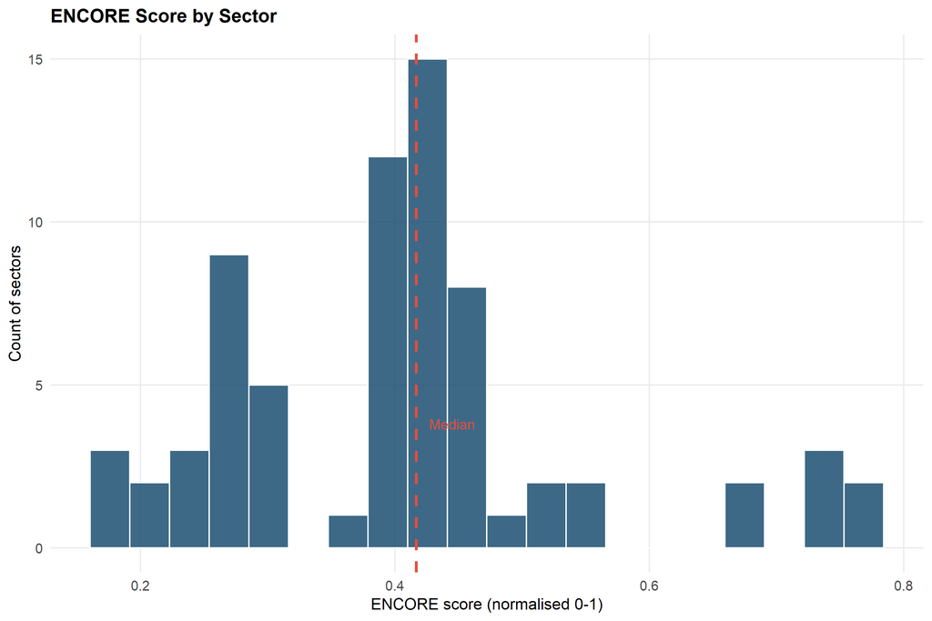

Distribution of ENCORE scores across sectors. Dashed line = median.

```r
p_enc <- df |>
  distinct(subrubroeconómico, score_share) |>
  ggplot(aes(score_share)) +
  geom_histogram(bins = 20, fill = col_high, alpha = 0.85, colour = "white") +
  geom_vline(xintercept = median(df$score_share, na.rm = TRUE),
             linetype = "dashed", colour = col_low, linewidth = 1) +
  annotate("text",
           x = median(df$score_share, na.rm = TRUE) + 0.01, y = 3.8,
           label = "Median", colour = col_low, hjust = 0, size = 3.5) +
  labs(title = "ENCORE Score by Sector",
       x = "ENCORE score (normalised 0-1)", y = "Count of sectors")

p_enc
```

```r
ggsave(dout("fig3_encore_dist.png"), plot = p_enc, width = 7, height = 5, dpi = 150)
```

# 3 Baseline TWFE Replication

We replicate the paper’s two main specifications using `fixest::feols()`.

## 3.1 Equation 1 — SMA Cases × ENCORE Score

$$\text{Loan}_{i,j,r,s,t} = \alpha_0 + \beta_1 \text{Cases}_{r,t-1} + \beta_2 \text{Score}_s + \beta_3(\text{Cases}_{r,t-1} \times \text{Score}_s) + \mu_{ij} + \delta_{st} + \omega_{jt} + u$$

```r
df_high <- df |>
  filter(score_share >= quantile(score_share, 0.25, na.rm = TRUE))

# Table 2 replication: cases only, high-ENCORE sample
m2_1 <- feols(lnewcred_w ~ log1p(lrcases) | bankfirm_id,
              data = df_high, cluster = ~IDR)
m2_2 <- feols(lnewcred_w ~ log1p(lrcases) | bankfirm_id + IDS^year,
              data = df_high, cluster = ~IDR)
m2_3 <- feols(lnewcred_w ~ log1p(lrcases) | bankfirm_id + IDS^year + IDB^year,
              data = df_high, cluster = ~IDR)

# Table 3 replication: interaction with continuous ENCORE score
m3_1 <- feols(lnewcred_w ~ log1p(lrcases) * score_share | bankfirm_id,
              data = df, cluster = ~IDR)
m3_2 <- feols(lnewcred_w ~ log1p(lrcases) * score_share | bankfirm_id + IDS^year,
              data = df, cluster = ~IDR)
m3_3 <- feols(lnewcred_w ~ log1p(lrcases) * score_share |
                bankfirm_id + IDS^year + IDB^year,
              data = df, cluster = ~IDR)

modelsummary(
  list("(1)" = m2_1, "(2)" = m2_2, "(3)" = m2_3,
       "(4)" = m3_1, "(5)" = m3_2, "(6)" = m3_3),
  title    = "Tables 2-3 Replication: Effect of SMA Cases on New Credit",
  stars    = c("*" = 0.1, "**" = 0.05, "***" = 0.01),
  coef_map = c(
    "log1p(lrcases)"             = "Log Cases (lag)",
    "score_share"                = "ENCORE score",
    "log1p(lrcases):score_share" = "Log Cases × ENCORE"
  ),
  gof_map  = c("nobs", "r.squared"),
  notes    = "Clustered SE by region only. Cols 1-3: above-p25 ENCORE sample.",
  output   = "kableExtra"
) |>
  add_header_above(c(" " = 1,
                     "Table 2: Cases only (above-p25 ENCORE)" = 3,
                     "Table 3: Cases × ENCORE (full sample)" = 3)) |>
  kable_styling(bootstrap_options = c("striped", "condensed"), full_width = FALSE)
```

Tables 2-3 Replication: Effect of SMA Cases on New Credit

|  | Table 2: Cases only (above-p25 ENCORE) &nbsp;(1) | Table 2: Cases only (above-p25 ENCORE) &nbsp;&nbsp;(2) | Table 2: Cases only (above-p25 ENCORE) &nbsp;&nbsp;(3) | Table 3: Cases × ENCORE (full sample) &nbsp;&nbsp;(4) | Table 3: Cases × ENCORE (full sample) &nbsp;&nbsp;(5) | Table 3: Cases × ENCORE (full sample) &nbsp;&nbsp;(6) |
| --- | --- | --- | --- | --- | --- | --- |
| Log Cases (lag) | −0.281*** | 0.379 | 0.396 | −0.247** | 0.073 | 0.109 |
|  | (0.047) | (0.255) | (0.258) | (0.098) | (0.648) | (0.582) |
| ENCORE score |  |  |  | 0.396 |  | −1.626 |
|  |  |  |  | (0.304) |  | (25142.481) |
| Log Cases × ENCORE |  |  |  | −0.038 | 0.523 | 0.497 |
|  |  |  |  | (0.139) | (0.970) | (0.882) |
| Num.Obs. | 346744 | 346722 | 346705 | 460292 | 460270 | 460254 |
| R2 | 0.387 | 0.477 | 0.480 | 0.401 | 0.489 | 0.492 |

* p < 0.1, ** p < 0.05, *** p < 0.01  
Clustered SE by region only. Cols 1-3: above-p25 ENCORE sample.

## 3.2 Equation 2 — Court Introduction × SMA Cases

$$\text{Loan}_{i,j,r,s,t} = \alpha_0 + \beta_1 \text{Cases}_{r,t-1} + \beta_2 \text{Court}_{r,t} + \beta_3(\text{Cases}_{r,t-1} \times \text{Court}_{r,t}) + \mu_{ij} + \delta_{st} + \omega_{jt} + u$$

The key coefficient is $\beta_3$: it captures whether judicial enforceability amplifies the credit response to regulatory pressure.

```r
m4_1 <- feols(lnewcred_w ~ log1p(lrcases) * court | bankfirm_id + IDS^year,
              data = df, cluster = ~IDR)
m4_2 <- feols(lnewcred_w ~ log1p(lrcases) * court |
                bankfirm_id + IDS^year + IDB^year,
              data = df, cluster = ~IDR)
m4_3 <- feols(lnewcred_w ~ log1p(lrcases) * court |
                bankfirm_id + IDS^year + IDB^year,
              data = df |> filter(d50_score == 1), cluster = ~IDR)
m4_4 <- feols(lnewcred_w ~ log1p(lrcases) * court |
                bankfirm_id + IDS^year + IDB^year,
              data = df |> filter(d50_score == 0), cluster = ~IDR)

modelsummary(
  list("Full (1)" = m4_1, "Full (2)" = m4_2,
       "High ENCORE" = m4_3, "Low ENCORE" = m4_4),
  title    = "Table 4 Replication: Court Introduction × SMA Cases",
  stars    = c("*" = 0.1, "**" = 0.05, "***" = 0.01),
  coef_map = c(
    "log1p(lrcases)"       = "Log Cases (lag)",
    "court"                = "Court",
    "log1p(lrcases):court" = "Log Cases × Court"
  ),
  gof_map  = c("nobs", "r.squared"),
  notes    = "Clustered SE by region only. Santiago excluded.",
  output   = "kableExtra"
) |>
  add_header_above(c(" " = 1, "Full sample" = 2, "By ENCORE exposure" = 2)) |>
  kable_styling(bootstrap_options = c("striped", "condensed"), full_width = FALSE)
```

Table 4 Replication: Court Introduction × SMA Cases

|  | Full sample Full (1) | Full sample &nbsp;Full (2) | By ENCORE exposure High ENCORE | By ENCORE exposure Low ENCORE |
| --- | --- | --- | --- | --- |
| Log Cases (lag) | 0.354 | 0.430* | 0.546* | 0.134 |
|  | (0.277) | (0.243) | (0.266) | (0.495) |
| Court | −0.074 | −0.065 | −0.075 | 0.070 |
|  | (0.060) | (0.062) | (0.074) | (0.223) |
| Log Cases × Court | 0.012 | −0.014 | −0.029 | −0.060 |
|  | (0.056) | (0.053) | (0.051) | (0.185) |
| Num.Obs. | 460270 | 460254 | 311389 | 148051 |
| R2 | 0.489 | 0.492 | 0.481 | 0.531 |

* p < 0.1, ** p < 0.05, *** p < 0.01  
Clustered SE by region only. Santiago excluded.

```r
# Wild cluster bootstrap p-value for the interaction coefficient in m4_2
m4_2_boot <- feols(
  lnewcred_w ~ log1p(lrcases) * court |
    bankfirm_id + IDS^year + IDB^year,
  data    = df,
  cluster = ~IDR
)

if (requireNamespace("wildboottest", quietly = TRUE) && .Platform$OS.type != "windows") {
  wb_m4_2 <- wildboottest::boottest(
    m4_2_boot,
    param   = "log1p(lrcases):court",
    clustid = "IDR",
    B       = 9999
  )
  print(wb_m4_2)
} else if (requireNamespace("wildboottest", quietly = TRUE) && .Platform$OS.type == "windows") {
  cat("wildboottest is installed, but its CLI backend can fail on Windows (TMPDIR command error).\n")
  cat("Run this block in WSL/Linux or use a Windows-compatible wild bootstrap package.\n")
} else {
  cat("wildboottest is not installed. Run install.packages('wildboottest') to compute wild bootstrap p-values.\n")
}
```

```
wildboottest is not installed. Run install.packages('wildboottest') to compute wild bootstrap p-values.
```

# 4 Callaway–Sant’Anna Staggered DiD

Standard TWFE can be biased when treatment effects are heterogeneous across cohorts, because it implicitly uses already-treated units as controls for later-treated units. The Callaway & Sant’Anna (2021) estimator avoids this by constructing clean 2×2 ATT(g,t) comparisons for each cohort $g$ and period $t$.

**Setup:**

```r
df_cs <- df |>
  filter(!is.na(lnewcred_w), !is.na(lrcases), !is.na(score_share)) |>
  mutate(year_court = as.integer(year_court))

# ── Aggregate to region-sector-year level for CS estimation ───────────────────
# CS requires a unit ID (rs_id) that is time-invariant; bank-firm pairs
# can move regions, so we collapse to region × sector.
df_rs_bal <- df_cs |>
  group_by(regid, subrubroeconómico, year) |>
  summarise(
    lnewcred_w  = mean(lnewcred_w,  na.rm = TRUE),
    lrcases     = first(lrcases),
    score_share = first(score_share),
    year_court  = first(year_court),
    .groups     = "drop"
  ) |>
  mutate(
    rs_id       = as.integer(interaction(regid, subrubroeconómico, drop = TRUE)),
    regid_fixed = regid
  )

# ── Fix: year_court must be time-invariant per rs_id ──────────────────────────
# Assign the modal year_court per region-sector to ensure irreversibility.
year_court_rs <- df_rs_bal |>
  group_by(rs_id) |>
  summarise(
    year_court = as.integer(names(which.max(table(year_court)))),
    .groups    = "drop"
  )

df_rs_bal <- df_rs_bal |>
  select(-year_court) |>
  left_join(year_court_rs, by = "rs_id")

cat("CS sample:", nrow(df_cs), "obs |",
    n_distinct(df_cs$bankfirm_id), "bank-firm pairs\n\n")
```

```
CS sample: 474785 obs | 104770 bank-firm pairs
```

```r
cat("Cohort distribution (bank-firm pairs):\n")
```

```
Cohort distribution (bank-firm pairs):
```

```r
df_cs |>
  distinct(bankfirm_id, year_court) |>
  count(year_court, name = "pairs") |>
  mutate(label = case_when(
    year_court == 0    ~ "Never treated",
    year_court == 2013 ~ "Santiago (g=2013)",
    year_court == 2014 ~ "Valdivia (g=2014)",
    year_court == 2017 ~ "Antofagasta (g=2017)"
  )) |>
  select(label, pairs) |>
  print()
```

```
# A tibble: 4 × 2
  label                pairs
  <chr>                <int>
1 Never treated        17535
2 Santiago (g=2013)    32010
3 Valdivia (g=2014)    38564
4 Antofagasta (g=2017) 16661
```

## 4.1 Main CS Estimates — Full Sample

```r
# ── Correr CS sin covariables ──────────────────────────────────────────────────
# lrcases es constante dentro de cada región-año → causa matriz singular.
# Corremos sin xformla primero para verificar identificación base.
cs_main <- att_gt(
  yname         = "lnewcred_w",
  tname         = "year",
  idname        = "rs_id",
  gname         = "year_court",
  xformla       = ~ 1,              # sin covariables
  data          = df_rs_bal,
  control_group = "notyettreated",
  est_method    = "reg",
  clustervars   = "regid_fixed",
  print_details = FALSE
)

summary(cs_main)
```

```
Call:
att_gt(yname = "lnewcred_w", tname = "year", idname = "rs_id",
    gname = "year_court", xformla = ~1, data = df_rs_bal, control_group = "notyettreated",
    clustervars = "regid_fixed", est_method = "reg", print_details = FALSE)

Reference: Callaway, Brantly and Pedro H.C. Sant'Anna.  "Difference-in-Differences with Multiple Time Periods." Journal of Econometrics, Vol. 225, No. 2, pp. 200-230, 2021. <https://doi.org/10.1016/j.jeconom.2020.12.001>, <https://arxiv.org/abs/1803.09015>

Group-Time Average Treatment Effects:
 Group Time ATT(g,t) Std. Error [95% Simult.  Conf. Band]
  2013 2012   0.0945     0.3835       -0.7450      0.9341
  2013 2013  -0.1856     0.2576       -0.7496      0.3783
  2013 2014   0.0093     0.4492       -0.9741      0.9927
  2013 2015   0.1899     0.4941       -0.8918      1.2715
  2013 2016   0.7203     0.5119       -0.4003      1.8409
  2014 2012  -0.1754     0.2914       -0.8132      0.4625
  2014 2013   0.3864     0.2502       -0.1614      0.9342
  2014 2014  -0.0430     0.3487       -0.8064      0.7203
  2014 2015   0.1827     0.3974       -0.6873      1.0526
  2014 2016   0.6663     0.3913       -0.1903      1.5229
---
Signif. codes: `*' confidence band does not cover 0

P-value for pre-test of parallel trends assumption:  0.61074
Control Group:  Not Yet Treated,  Anticipation Periods:  0
Estimation Method:  Outcome Regression
```

## 4.2 Aggregated ATT

```r
cs_simple   <- aggte(cs_main, type = "simple")
cs_group    <- aggte(cs_main, type = "group")
cs_dynamic  <- aggte(cs_main, type = "dynamic", min_e = -3, max_e = 8)
cs_calendar <- aggte(cs_main, type = "calendar")

cat("─── Simple ATT ────────────────────────────────────────────────\n")
```

```
─── Simple ATT ────────────────────────────────────────────────
```

```r
cat(sprintf("  ATT = %.4f  |  SE = %.4f  |  95%% CI: [%.4f, %.4f]\n",
    cs_simple$overall.att,
    cs_simple$overall.se,
    cs_simple$overall.att - 1.96 * cs_simple$overall.se,
    cs_simple$overall.att + 1.96 * cs_simple$overall.se))
```

```
  ATT = 0.2269  |  SE = 0.2798  |  95% CI: [-0.3215, 0.7753]
```

```r
cat("\n─── ATT by cohort ─────────────────────────────────────────────\n")
```

```
─── ATT by cohort ─────────────────────────────────────────────
```

```r
tibble(
  cohort  = cs_group$egt,
  ATT     = round(cs_group$att.egt, 4),
  SE      = round(cs_group$se.egt,  4)
) |>
  mutate(`95% CI` = sprintf("[%.4f, %.4f]",
                             ATT - 1.96 * SE, ATT + 1.96 * SE)) |>
  print()
```

```
# A tibble: 2 × 4
  cohort   ATT    SE `95% CI`
   <int> <dbl> <dbl> <chr>
1   2013 0.184 0.359 [-0.5197, 0.8867]
2   2014 0.269 0.280 [-0.2792, 0.8164]
```

```r
# ── Helper: tidy a CS dynamic aggregate into a tibble ─────────────────────────
tidy_cs <- function(cs_dyn, label) {
  tibble(
    event_time = cs_dyn$egt,
    att        = cs_dyn$att.egt,
    se         = cs_dyn$se.egt,
    group      = label
  ) |>
    mutate(ci_lo = att - 1.96 * se,
           ci_hi = att + 1.96 * se)
}
```

## 4.3 CS by ENCORE Subgroup

```r
# ── High ENCORE ────────────────────────────────────────────────────────────────
cs_high <- att_gt(
  yname         = "lnewcred_w",
  tname         = "year",
  idname        = "rs_id",
  gname         = "year_court",
  xformla       = ~ 1,
  data          = df_rs_bal |> filter(score_share >= median(score_share, na.rm = TRUE)),
  control_group = "notyettreated",
  est_method    = "reg",
  clustervars   = "regid_fixed",
  print_details = FALSE
)

# ── Low ENCORE ─────────────────────────────────────────────────────────────────
cs_low <- att_gt(
  yname         = "lnewcred_w",
  tname         = "year",
  idname        = "rs_id",
  gname         = "year_court",
  xformla       = ~ 1,
  data          = df_rs_bal |> filter(score_share < median(score_share, na.rm = TRUE)),
  control_group = "notyettreated",
  est_method    = "reg",
  clustervars   = "regid_fixed",
  print_details = FALSE
)

# ── Aggregate ──────────────────────────────────────────────────────────────────
cs_high_dyn <- aggte(cs_high, type = "dynamic", min_e = -3, max_e = 6)
cs_low_dyn  <- aggte(cs_low,  type = "dynamic", min_e = -3, max_e = 6)

cat("High ENCORE — simple ATT:",
    round(aggte(cs_high, "simple")$overall.att, 4), "\n")
```

```
High ENCORE — simple ATT: 0.1637
```

```r
cat("Low  ENCORE — simple ATT:",
    round(aggte(cs_low,  "simple")$overall.att, 4), "\n")
```

```
Low  ENCORE — simple ATT: 0.3705
```

## 4.4 Robustness: Control Group Definition

The main CS specification defines the control group as a mix of two types of units: (1) firms with `score_share < 0.2` reclassified as never-treated (sector-based exclusion), and (2) firms in regions not yet treated at each calendar year (geographic not-yet-treated). These two groups are conceptually distinct. This section checks whether results are sensitive to which type of control group drives identification.

Three specifications are compared:

- **Baseline**: never-treated (low ENCORE) + not-yet-treated (what the main spec uses)
- **Robustness A**: only never-treated (low ENCORE firms, `score_share < 0.2`), using `control_group = "nevertreated"` — isolates purely sectoral variation
- **Robustness B**: only not-yet-treated (geographic timing variation only), panel truncated to 2011–2016 to avoid the absence of controls for g=2017 after all regions are treated

```r
# ── Robustness A: solo never-treated (low ENCORE) como control ─────────────────
# Usa nevertreated en vez de notyettreated — solo variación sectorial
cs_robA <- att_gt(
  yname         = "lnewcred_w",
  tname         = "year",
  idname        = "rs_id",
  gname         = "year_court",
  xformla       = ~ 1,
  data          = df_rs_bal,
  control_group = "nevertreated",   # <-- cambio clave respecto al baseline
  est_method    = "reg",
  clustervars   = "regid_fixed",
  print_details = FALSE
)

# ── Robustness B: solo not-yet-treated (variación geográfica de timing) ────────
# Excluye las firmas never-treated artificiales (low ENCORE).
# Trunca el panel a 2011-2016 para evitar que g=2017 quede sin controles
# válidos una vez que Antofagasta se trata.
df_robB <- df_rs_bal |>
  filter(year <= 2016) |>        # antes de que todas las regiones estén tratadas
  filter(year_court != 0)        # excluye never-treated artificiales (low ENCORE)

cs_robB <- att_gt(
  yname         = "lnewcred_w",
  tname         = "year",
  idname        = "rs_id",
  gname         = "year_court",
  xformla       = ~ 1,
  data          = df_robB,
  control_group = "notyettreated",
  est_method    = "reg",
  clustervars   = "regid_fixed",
  print_details = FALSE
)

# ── Agregar ATT simples ────────────────────────────────────────────────────────
cs_robA_simple <- aggte(cs_robA, type = "simple")
cs_robB_simple <- aggte(cs_robB, type = "simple")

# ── Tabla comparativa ─────────────────────────────────────────────────────────
rob_comp <- tribble(
  ~Specification,                        ~Control_group,                          ~ATT,                       ~SE,
  "Baseline (main)",                     "Low ENCORE (never) + not-yet-treated",  cs_simple$overall.att,      cs_simple$overall.se,
  "Robustness A: never-treated only",    "Low ENCORE only (score_share < 0.2)",   cs_robA_simple$overall.att, cs_robA_simple$overall.se,
  "Robustness B: not-yet-treated only",  "Not-yet-treated only (2011–2016)",       cs_robB_simple$overall.att, cs_robB_simple$overall.se
) |>
  mutate(
    ci_lo = round(ATT - 1.96 * SE, 4),
    ci_hi = round(ATT + 1.96 * SE, 4),
    ATT   = round(ATT, 4),
    SE    = round(SE,  4)
  )

rob_comp |>
  gt() |>
  tab_header(
    title    = "Robustness: Sensitivity to Control Group Definition",
    subtitle = "Are CS results driven by how the control group is constructed?"
  ) |>
  fmt_number(columns = where(is.numeric), decimals = 4) |>
  cols_label(
    Specification = "Specification",
    Control_group = "Control group",
    ci_lo         = "CI low",
    ci_hi         = "CI high"
  ) |>
  tab_footnote(
    "Robustness B truncates panel to 2011–2016 to avoid the complete
     absence of not-yet-treated units after g=2017 (Antofagasta) is treated.
     Robustness A uses nevertreated instead of notyettreated in att_gt()."
  )
```

Robustness: Sensitivity to Control Group Definition

Are CS results driven by how the control group is constructed?

| Specification | Control group | ATT | SE | CI low | CI high |
| --- | --- | --- | --- | --- | --- |
| Baseline (main) | Low ENCORE (never) + not-yet-treated | 0.2269 | 0.2798 | −0.3215 | 0.7753 |
| Robustness A: never-treated only | Low ENCORE only (score_share < 0.2) | 0.2543 | 0.2691 | −0.2732 | 0.7819 |
| Robustness B: not-yet-treated only | Not-yet-treated only (2011–2016) | −0.3607 | 0.3409 | −1.0289 | 0.3075 |

Robustness B truncates panel to 2011–2016 to avoid the complete absence of not-yet-treated units after g=2017 (Antofagasta) is treated. Robustness A uses nevertreated instead of notyettreated in att_gt().

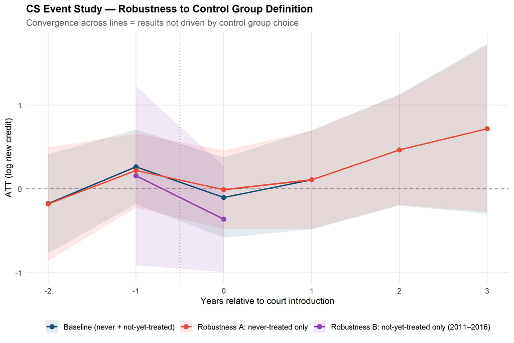

CS event study under three control group definitions. If the lines align, results are not driven by the choice of control group.

```r
cs_robA_dyn <- aggte(cs_robA, type = "dynamic", min_e = -3, max_e = 6)
cs_robB_dyn <- aggte(cs_robB, type = "dynamic", min_e = -3, max_e = 3)

es_rob <- bind_rows(
  tidy_cs(cs_dynamic,  "Baseline (never + not-yet-treated)"),
  tidy_cs(cs_robA_dyn, "Robustness A: never-treated only"),
  tidy_cs(cs_robB_dyn, "Robustness B: not-yet-treated only (2011–2016)")
)

ggplot(es_rob, aes(event_time, att, colour = group, fill = group)) +
  geom_hline(yintercept = 0, linetype = "dashed", colour = "grey50") +
  geom_vline(xintercept = -0.5, linetype = "dotted", colour = "grey40") +
  geom_ribbon(aes(ymin = ci_lo, ymax = ci_hi), alpha = 0.12, colour = NA) +
  geom_line(linewidth = 0.9) +
  geom_point(size = 2.5) +
  scale_colour_manual(values = c("#1B4F72", "#E74C3C", "#8E44AD")) +
  scale_fill_manual(values   = c("#1B4F72", "#E74C3C", "#8E44AD")) +
  scale_x_continuous(breaks  = -3:8) +
  labs(
    title    = "CS Event Study — Robustness to Control Group Definition",
    subtitle = "Convergence across lines = results not driven by control group choice",
    x        = "Years relative to court introduction",
    y        = "ATT (log new credit)",
    colour   = NULL, fill = NULL
  ) +
  theme(legend.position = "bottom")
```

```r
ggsave(dout("fig_robustness_control_group.png"), width = 10, height = 6, dpi = 150)
```

> **How to read this:** If Robustness A (never-treated only) and Baseline converge but Robustness B diverges, identification is coming primarily from sectoral variation (low ENCORE firms), not geographic timing. If Robustness B fails to run or has very wide CIs, that confirms the g=2017 identification problem: without not-yet-treated units after 2017, the geographic timing variation alone is weak for the Antofagasta cohort.

```r
# ── Clasificar regiones por intensidad de enforcement pre-tratamiento ──────────
# Usamos el promedio de lrcases ANTES de la entrada del tribunal
# para evitar endogeneidad — la intensidad es pre-determinada
enforcement_intensity <- df_rs_bal |>
  filter(year < year_court | year_court == 0) |>
  group_by(regid_fixed) |>
  summarise(mean_cases = mean(lrcases, na.rm = TRUE), .groups = "drop") |>
  mutate(
    high_enforce = as.integer(mean_cases >= median(mean_cases, na.rm = TRUE))
  )

cat("Regiones por intensidad de enforcement:\n")
```

```
Regiones por intensidad de enforcement:
```

```r
enforcement_intensity |>
  mutate(label = if_else(high_enforce == 1, "High enforcement", "Low enforcement")) |>
  count(label) |> print()
```

```
# A tibble: 2 × 2
  label                n
  <chr>            <int>
1 High enforcement     8
2 Low enforcement      7
```

```r
# Merge back
df_rs_bal <- df_rs_bal |>
  left_join(enforcement_intensity |> select(regid_fixed, mean_cases, high_enforce),
            by = "regid_fixed")

# ── CS: regiones con enforcement ALTO ─────────────────────────────────────────
cs_high_enforce <- att_gt(
  yname         = "lnewcred_w",
  tname         = "year",
  idname        = "rs_id",
  gname         = "year_court",
  xformla       = ~ 1,
  data          = df_rs_bal |> filter(high_enforce == 1),
  control_group = "notyettreated",
  est_method    = "reg",
  clustervars   = "regid_fixed",
  print_details = FALSE
)

# ── CS: regiones con enforcement BAJO ─────────────────────────────────────────
cs_low_enforce <- att_gt(
  yname         = "lnewcred_w",
  tname         = "year",
  idname        = "rs_id",
  gname         = "year_court",
  xformla       = ~ 1,
  data          = df_rs_bal |> filter(high_enforce == 0),
  control_group = "notyettreated",
  est_method    = "reg",
  clustervars   = "regid_fixed",
  print_details = FALSE
)

# ── Aggregate ──────────────────────────────────────────────────────────────────
cs_he_simple <- aggte(cs_high_enforce, type = "simple")
cs_le_simple <- aggte(cs_low_enforce,  type = "simple")

cs_he_dyn <- aggte(cs_high_enforce, type = "dynamic", min_e = -2, max_e = 2)
cs_le_dyn <- aggte(cs_low_enforce,  type = "dynamic", min_e = -2, max_e = 2)

cat("\nSimple ATT by enforcement intensity:\n")
```

```
Simple ATT by enforcement intensity:
```

```r
tibble(
  Group = c("High enforcement", "Low enforcement"),
  ATT   = round(c(cs_he_simple$overall.att, cs_le_simple$overall.att), 4),
  SE    = round(c(cs_he_simple$overall.se,  cs_le_simple$overall.se),  4)
) |>
  mutate(`95% CI` = sprintf("[%.3f, %.3f]",
                             ATT - 1.96 * SE,
                             ATT + 1.96 * SE)) |>
  print()
```

```
# A tibble: 2 × 4
  Group                ATT    SE `95% CI`
  <chr>              <dbl> <dbl> <chr>
1 High enforcement -0.0095 0.342 [-0.679, 0.660]
2 Low enforcement  -0.028  0.262 [-0.542, 0.486]
```

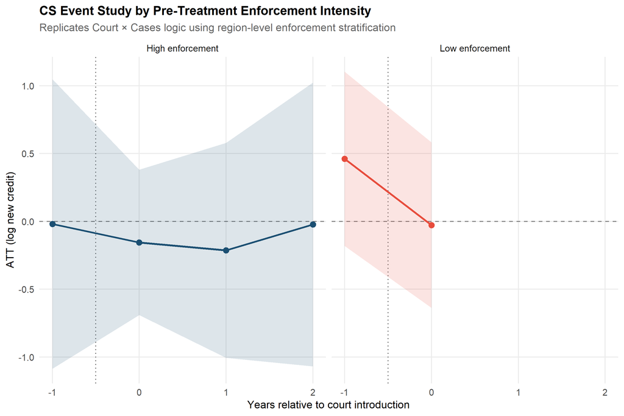

```r
# ── Event study plot ───────────────────────────────────────────────────────────
es_enforce <- bind_rows(
  tidy_cs(cs_he_dyn, "High enforcement"),
  tidy_cs(cs_le_dyn, "Low enforcement")
)

ggplot(es_enforce, aes(event_time, att, colour = group, fill = group)) +
  geom_hline(yintercept = 0, linetype = "dashed", colour = "grey50") +
  geom_vline(xintercept = -0.5, linetype = "dotted", colour = "grey40") +
  geom_ribbon(aes(ymin = ci_lo, ymax = ci_hi), alpha = 0.15, colour = NA) +
  geom_line(linewidth = 0.9) +
  geom_point(size = 2.5) +
  scale_colour_manual(values = c(col_high, col_low)) +
  scale_fill_manual(values   = c(col_high, col_low)) +
  scale_x_continuous(breaks  = -2:2) +
  facet_wrap(~group, ncol = 2) +
  labs(
    title    = "CS Event Study by Pre-Treatment Enforcement Intensity",
    subtitle = "Replicates Court × Cases logic using region-level enforcement stratification",
    x        = "Years relative to court introduction",
    y        = "ATT (log new credit)",
    colour   = NULL, fill = NULL
  ) +
  theme(legend.position = "none")
```

```r
ggsave(dout("fig_cs_enforcement.png"), width = 10, height = 5, dpi = 150)
```

# 5 Wooldridge ETWFE — Robustness

As an additional robustness check we implement the Wooldridge (2021) **Extended TWFE (ETWFE)** estimator. This saturates interactions between cohort dummies, period dummies, and the continuous enforcement variable (`lrcases`), avoiding negative weighting while remaining in a familiar regression framework.

```r
df_w <- df |>
  mutate(
    d2013 = as.integer(year_court == 2013),
    d2014 = as.integer(year_court == 2014),
    d2017 = as.integer(year_court == 2017),
    dinf  = as.integer(year_court == 0),
    f2013 = as.integer(year == 2013),
    f2014 = as.integer(year == 2014),
    f2015 = as.integer(year == 2015),
    f2016 = as.integer(year == 2016),
    f2017 = as.integer(year == 2017),
    f2018 = as.integer(year == 2018),
    f2019 = as.integer(year == 2019),
    f2020 = as.integer(year == 2020),
    # Time-invariant region ID for clustering
    IDR_fixed = as.integer(factor(regid))
  )

# ── Mean-centre lrcases within each cohort (correct grouping) ─────────────────
mean_rc <- df_w |>
  group_by(year_court) |>
  summarise(mean_lrcases = mean(lrcases, na.rm = TRUE), .groups = "drop")

df_w <- df_w |>
  left_join(mean_rc, by = "year_court") |>
  mutate(
    rc_dm13 = if_else(d2013 == 1, lrcases - mean_lrcases, 0),
    rc_dm14 = if_else(d2014 == 1, lrcases - mean_lrcases, 0),
    rc_dm17 = if_else(d2017 == 1, lrcases - mean_lrcases, 0)
  ) |>
  select(-mean_lrcases)

# ── ETWFE: saturated cohort × period × cases interactions ─────────────────────
etwfe <- feols(
  lnewcred_w ~
    # Cohort 2013: post-treatment periods
    I(d2013 * rc_dm13 * f2013) + I(d2013 * rc_dm13 * f2014) +
    I(d2013 * rc_dm13 * f2015) + I(d2013 * rc_dm13 * f2016) +
    I(d2013 * rc_dm13 * f2017) + I(d2013 * rc_dm13 * f2018) +
    I(d2013 * rc_dm13 * f2019) + I(d2013 * rc_dm13 * f2020) +
    # Cohort 2014: post-treatment periods
    I(d2014 * rc_dm14 * f2014) + I(d2014 * rc_dm14 * f2015) +
    I(d2014 * rc_dm14 * f2016) + I(d2014 * rc_dm14 * f2017) +
    I(d2014 * rc_dm14 * f2018) + I(d2014 * rc_dm14 * f2019) +
    I(d2014 * rc_dm14 * f2020) +
    # Cohort 2017: post-treatment periods
    I(d2017 * rc_dm17 * f2017) + I(d2017 * rc_dm17 * f2018) +
    I(d2017 * rc_dm17 * f2019) + I(d2017 * rc_dm17 * f2020) |
    bankfirm_id + IDS^year + IDB^year,
  data    = df_w,
  cluster = ~IDR_fixed
)

# ── Compute weighted average ATT across cohort-period cells ───────────────────
etwfe_coefs <- coef(etwfe)
etwfe_coefs <- etwfe_coefs[!is.na(etwfe_coefs)]
cat("ETWFE — average marginal effect (unweighted mean of cohort-period coefs):\n")
```

```
ETWFE — average marginal effect (unweighted mean of cohort-period coefs):
```

```r
cat("  Mean =", round(mean(etwfe_coefs), 4), "\n")
```

```
  Mean = -0.0015
```

```r
cat("  Range: [", round(min(etwfe_coefs), 4), ",",
                  round(max(etwfe_coefs), 4), "]\n\n")
```

```
  Range: [ -0.2909 , 0.2358 ]
```

```r
# ── Table ──────────────────────────────────────────────────────────────────────
modelsummary(
  list("ETWFE (Wooldridge 2021)" = etwfe),
  title   = "Robustness: Wooldridge ETWFE with Continuous Treatment",
  stars   = c("*" = 0.1, "**" = 0.05, "***" = 0.01),
  gof_map = c("nobs", "r.squared"),
  notes   = paste(
    "Each coefficient is a cohort × period × SMA cases interaction.",
    "lrcases is mean-centred within each treatment cohort.",
    "Clustered SE by region only."
  ),
  output  = "kableExtra"
) |>
  kable_styling(bootstrap_options = c("striped", "condensed"), full_width = FALSE)
```

Robustness: Wooldridge ETWFE with Continuous Treatment

|  | &nbsp;ETWFE (Wooldridge 2021) |
| --- | --- |
| I(d2013 * rc_dm13 * f2013) | 0.007 |
|  | (0.018) |
| I(d2013 * rc_dm13 * f2014) | −0.017 |
|  | (0.058) |
| I(d2013 * rc_dm13 * f2015) | 0.033 |
|  | (0.050) |
| I(d2013 * rc_dm13 * f2016) | 0.070 |
|  | (0.053) |
| I(d2013 * rc_dm13 * f2017) | −0.023 |
|  | (0.049) |
| I(d2013 * rc_dm13 * f2018) | 0.002 |
|  | (0.075) |
| I(d2013 * rc_dm13 * f2019) | 0.236 |
|  | (0.161) |
| I(d2013 * rc_dm13 * f2020) | 0.141 |
|  | (0.198) |
| I(d2014 * rc_dm14 * f2014) | −0.032 |
|  | (0.054) |
| I(d2014 * rc_dm14 * f2015) | 0.095 |
|  | (0.060) |
| I(d2014 * rc_dm14 * f2016) | 0.110** |
|  | (0.051) |
| I(d2014 * rc_dm14 * f2017) | 0.004 |
|  | (0.082) |
| I(d2014 * rc_dm14 * f2018) | 0.030 |
|  | (0.102) |
| I(d2014 * rc_dm14 * f2019) | 0.032 |
|  | (0.109) |
| I(d2014 * rc_dm14 * f2020) | 0.228* |
|  | (0.120) |
| I(d2017 * rc_dm17 * f2017) | −0.261** |
|  | (0.103) |
| I(d2017 * rc_dm17 * f2018) | −0.291** |
|  | (0.125) |
| I(d2017 * rc_dm17 * f2019) | −0.222 |
|  | (0.154) |
| I(d2017 * rc_dm17 * f2020) | −0.169** |
|  | (0.061) |
| Num.Obs. | 460254 |
| R2 | 0.492 |

* p < 0.1, ** p < 0.05, *** p < 0.01  
Each coefficient is a cohort × period × SMA cases interaction. lrcases is mean-centred within each treatment cohort. Clustered SE by region only.

# 6 Event Study Plots

## 6.1 Callaway–Sant’Anna Event Study

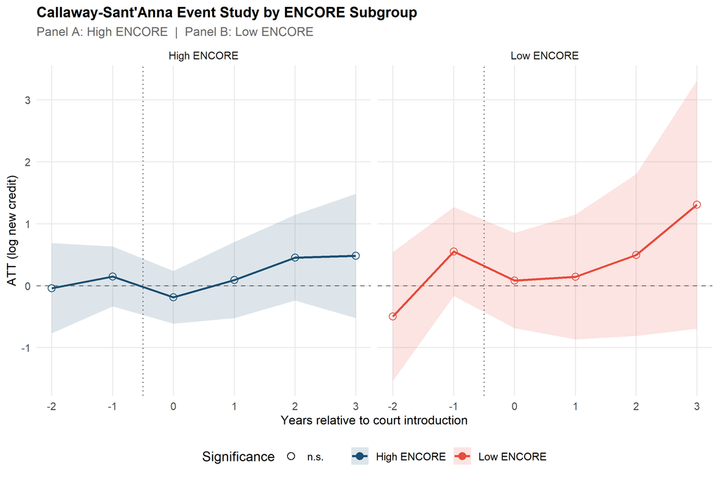

CS event study by ENCORE subgroup. Shaded area = 95% CI. Solid points = statistically significant at 5%.

```r
es_data <- bind_rows(
  tidy_cs(cs_high_dyn, "High ENCORE"),
  tidy_cs(cs_low_dyn,  "Low ENCORE")
) |>
  mutate(sig = factor(if_else(ci_lo > 0 | ci_hi < 0, "p<0.05", "n.s."),
                      levels = c("p<0.05", "n.s.")))

# Breaks dinámicos basados en los event times disponibles
et_range <- range(es_data$event_time, na.rm = TRUE)

ggplot(es_data, aes(event_time, att, colour = group, fill = group)) +
  geom_hline(yintercept = 0, linetype = "dashed", colour = "grey50") +
  geom_vline(xintercept = -0.5, linetype = "dotted", colour = "grey40") +
  geom_ribbon(aes(ymin = ci_lo, ymax = ci_hi), alpha = 0.15, colour = NA) +
  geom_line(linewidth = 0.9) +
  geom_point(aes(shape = sig), size = 2.8) +
  scale_colour_manual(values = c(col_high, col_low)) +
  scale_fill_manual(values   = c(col_high, col_low)) +
  scale_shape_manual(values  = c("p<0.05" = 19, "n.s." = 1)) +
  scale_x_continuous(breaks  = seq(et_range[1], et_range[2], by = 1)) +
  facet_wrap(~group, ncol = 2) +
  labs(
    title    = "Callaway-Sant'Anna Event Study by ENCORE Subgroup",
    subtitle = "Panel A: High ENCORE  |  Panel B: Low ENCORE",
    x        = "Years relative to court introduction",
    y        = "ATT (log new credit)",
    colour   = NULL, fill = NULL, shape = "Significance"
  ) +
  theme(legend.position = "bottom")
```

```r
ggsave(dout("fig4_cs_event_study_encore.png"), width = 10, height = 6, dpi = 150)
```

```r
#| label: event-cohort-cases
#| fig-cap: "Event study by treatment cohort interacted with log SMA cases. Coefficients represent the marginal effect of log SMA cases on log new credit relative to one year before court introduction (τ = -1). Shaded area = 95% CI. Filled markers = significant at 5%."

# ── Reconstruir df_es incluyendo RM ───────────────────────────────────────────
# A diferencia de df (que excluye regid=13), aquí incluimos la RM
# porque el tribunal de Santiago cubre la RM y su exclusión
# puede atenuar el efecto para g=2013

df_es <- cmf_annual |>
  # Solo excluir filas sin región o sin ENCORE — mantener RM
  filter(!is.na(regid), !is.na(score_share)) |>
  mutate(
    lnewcred    = log1p(newcred_cartera),
    lnewcred_w  = Winsorize(lnewcred,
                            quantile(lnewcred, probs = c(0.01, 0.99),
                                     na.rm = TRUE)),
    bankfirm_id = as.integer(interaction(ins_cod, id, drop = TRUE)),
    IDB         = as.integer(factor(ins_cod)),
    IDR         = as.integer(factor(regid)),
    IDS         = as.integer(factor(subrubroeconómico)),
    IDR_fixed   = as.integer(factor(regid)),
    # Event time relativo a entrada del tribunal
    event_time  = if_else(year_court > 0,
                          as.integer(year - year_court),
                          NA_integer_),
    event_time_w = case_when(
      event_time < -3 ~ -3L,
      event_time >  6 ~  6L,
      TRUE            ~ event_time
    )
  )

cat("df_es con RM incluida:\n")
```

```
df_es con RM incluida:
```

```r
cat("  Obs:    ", nrow(df_es), "\n")
```

```
  Obs:     851472
```

```r
cat("  Regiones:", n_distinct(df_es$regid), "(incluyendo RM)\n")
```

```
  Regiones: 16 (incluyendo RM)
```

```r
cat("  Cohorte dist:\n")
```

```
  Cohorte dist:
```

```r
df_es |> distinct(bankfirm_id, year_court) |> count(year_court) |> print()
```

```
# A tibble: 3 × 2
  year_court      n
       <int>  <int>
1       2013 128001
2       2014  42571
3       2017  18653
```

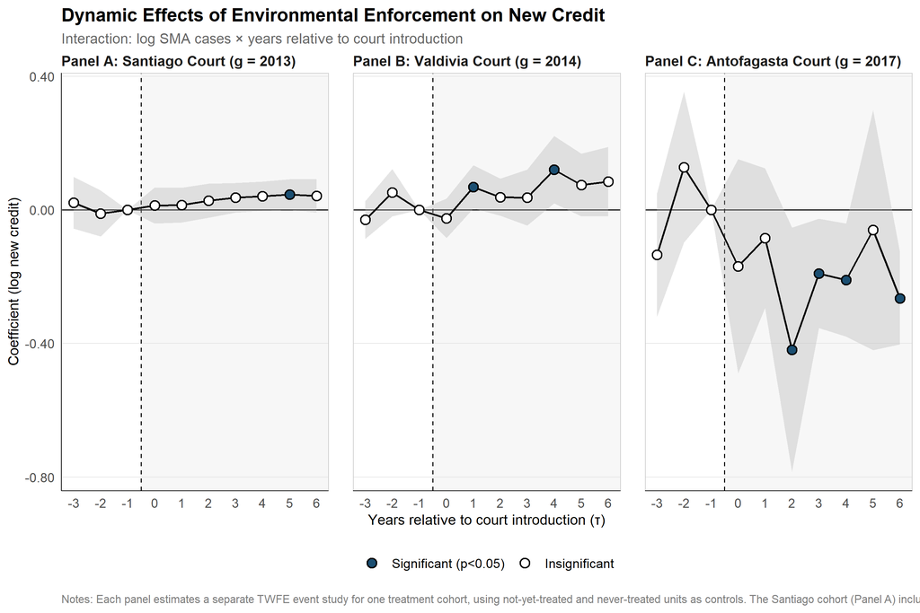

```r
# ── Función estimación ─────────────────────────────────────────────────────────
run_es_cohort <- function(cohort_year, data) {
  data |>
    filter(year_court == cohort_year |
           year_court == 0           |
           year_court > cohort_year) |>
    filter(!is.na(event_time_w) | year_court != cohort_year) |>
    mutate(
      event_time_w = replace_na(event_time_w, -1L),
      event_time_f = relevel(factor(event_time_w), ref = "-1")
    ) |>
    feols(
      lnewcred_w ~ i(event_time_f, lrcases, ref = "-1") |
        bankfirm_id + IDS^year + IDB^year,
      data    = _,
      cluster = ~IDR_fixed
    )
}

# ── Estimar los 3 modelos ──────────────────────────────────────────────────────
es_2013 <- run_es_cohort(2013, df_es)
es_2014 <- run_es_cohort(2014, df_es)
es_2017 <- run_es_cohort(2017, df_es)

# ── Extraer coeficientes ───────────────────────────────────────────────────────
tidy_es <- function(model, label) {
  broom::tidy(model, conf.int = TRUE) |>
    filter(str_detect(term, "event_time_f")) |>
    mutate(
      event_time = as.integer(str_extract(term, "-?\\d+")),
      cohort     = label
    ) |>
    select(event_time, estimate, conf.low, conf.high, p.value, cohort) |>
    bind_rows(
      tibble(event_time = -1L, estimate = 0,
             conf.low = 0, conf.high = 0,
             p.value  = 1, cohort = label)
    ) |>
    arrange(event_time) |>
    mutate(
      sig_lab = factor(if_else(p.value < 0.05,
                               "Significant (p<0.05)",
                               "Insignificant"),
                       levels = c("Significant (p<0.05)", "Insignificant"))
    )
}

es_data <- bind_rows(
  tidy_es(es_2013, "Panel A: Santiago Court (g = 2013)"),
  tidy_es(es_2014, "Panel B: Valdivia Court (g = 2014)"),
  tidy_es(es_2017, "Panel C: Antofagasta Court (g = 2017)")
) |>
  mutate(cohort = factor(cohort, levels = c(
    "Panel A: Santiago Court (g = 2013)",
    "Panel B: Valdivia Court (g = 2014)",
    "Panel C: Antofagasta Court (g = 2017)"
  )))

# ── Plot estilo paper ──────────────────────────────────────────────────────────
ggplot(es_data, aes(event_time, estimate)) +

  # Zona post-tratamiento sombreada
  annotate("rect", xmin = -0.5, xmax = Inf,
           ymin = -Inf, ymax = Inf,
           fill = "grey90", alpha = 0.3) +

  # Líneas de referencia
  geom_hline(yintercept = 0,    colour = "black", linewidth = 0.4) +
  geom_vline(xintercept = -0.5, colour = "black",
             linewidth  = 0.4,  linetype = "dashed") +

  # CI sombreado
  geom_ribbon(aes(ymin = conf.low, ymax = conf.high),
              fill = "grey70", alpha = 0.35, colour = NA) +

  # Línea principal
  geom_line(colour = "black", linewidth = 0.6) +

  # Puntos: relleno azul si sig, blanco si n.s.
  geom_point(aes(fill = sig_lab),
             shape = 21, size = 2.8,
             colour = "black", stroke = 0.7) +
  scale_fill_manual(
    values = c("Significant (p<0.05)" = col_high,
               "Insignificant"        = "white"),
    name   = NULL
  ) +

  scale_x_continuous(breaks = -3:6) +
  scale_y_continuous(labels = number_format(accuracy = 0.01)) +

  facet_wrap(~cohort, ncol = 3, scales = "fixed") +

  labs(
    title   = "Dynamic Effects of Environmental Enforcement on New Credit",
    subtitle = "Interaction: log SMA cases × years relative to court introduction",
    x       = "Years relative to court introduction (τ)",
    y       = "Coefficient (log new credit)",
    caption = paste(
      "Notes: Each panel estimates a separate TWFE event study for one treatment cohort,",
      "using not-yet-treated and never-treated units as controls.",
      "The Santiago cohort (Panel A) includes the Metropolitan Region.",
      "Reference period τ = −1. Shaded area = 95% CI.",
      "Filled markers = significant at 5% level.",
      "FE: bank×firm, sector×year, bank×year.",
      "SE clustered by region only."
    )
  ) +

  theme_minimal(base_size = 11) +
  theme(
    plot.title       = element_text(face = "bold", size = 13, hjust = 0),
    plot.subtitle    = element_text(colour = "grey40", size = 10, hjust = 0),
    plot.caption     = element_text(colour = "grey50", size = 8,
                                    hjust = 0, margin = margin(t = 8)),
    strip.text       = element_text(face = "bold", size = 10, hjust = 0,
                                    margin = margin(b = 4)),
    strip.background = element_blank(),
    axis.title       = element_text(size = 10),
    axis.text        = element_text(size = 9),
    axis.line        = element_line(colour = "black", linewidth = 0.3),
    panel.grid.major.x = element_blank(),
    panel.grid.minor   = element_blank(),
    panel.grid.major.y = element_line(colour = "grey90", linewidth = 0.3),
    panel.border     = element_rect(colour = "grey80", fill = NA,
                                    linewidth = 0.4),
    legend.position  = "bottom",
    legend.text      = element_text(size = 9),
    panel.spacing    = unit(1.2, "lines")
  )
```

```r
ggsave(dout("fig_event_cohort_cases.png"),
       width = 12, height = 5, dpi = 300)
```

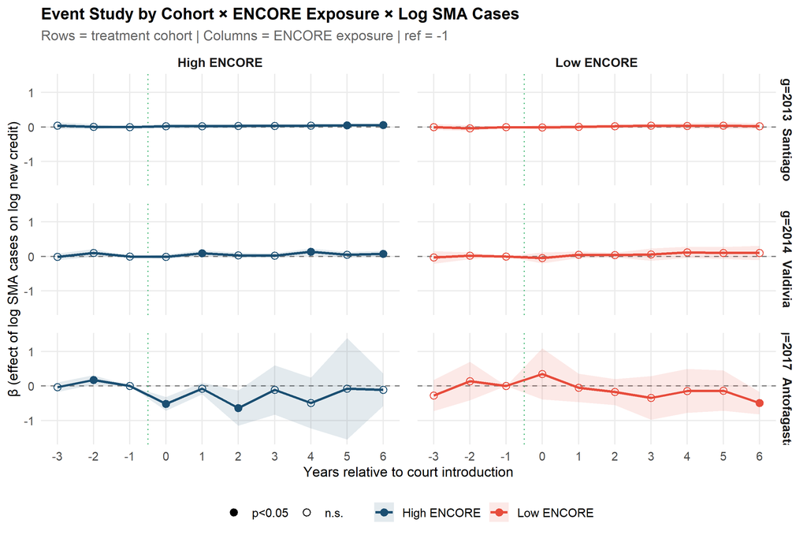

Event study by cohort × log SMA cases, split by ENCORE exposure. Each row is a cohort, each column is High/Low ENCORE.

```r
# ── Función extendida: cohorte × ENCORE ───────────────────────────────────────
run_es_cohort_encore <- function(cohort_year, encore_label, data) {

  encore_med <- median(data$score_share, na.rm = TRUE)

  df_cohort <- data |>
    filter(
      year_court == cohort_year |
      year_court == 0           |
      year_court > cohort_year
    ) |>
    filter(!is.na(event_time_w) | year_court != cohort_year) |>
    mutate(
      encore_group = if_else(score_share >= encore_med,
                             "High ENCORE", "Low ENCORE"),
      event_time_w = replace_na(event_time_w, -1L),
      event_time_f = relevel(factor(event_time_w), ref = "-1")
    ) |>
    filter(encore_group == encore_label)

  feols(
    lnewcred_w ~ i(event_time_f, lrcases, ref = "-1") |
      bankfirm_id + IDS^year + IDB^year,
    data    = df_cohort,
    cluster = ~IDR_fixed
  )
}

# ── Estimar 6 modelos (3 cohortes × 2 grupos ENCORE) ─────────────────────────
models <- list(
  list(cohort = 2013, encore = "High ENCORE", label = "g=2013  Santiago"),
  list(cohort = 2013, encore = "Low ENCORE",  label = "g=2013  Santiago"),
  list(cohort = 2014, encore = "High ENCORE", label = "g=2014  Valdivia"),
  list(cohort = 2014, encore = "Low ENCORE",  label = "g=2014  Valdivia"),
  list(cohort = 2017, encore = "High ENCORE", label = "g=2017  Antofagasta"),
  list(cohort = 2017, encore = "Low ENCORE",  label = "g=2017  Antofagasta")
)

results <- map(models, function(m) {
  fit <- run_es_cohort_encore(m$cohort, m$encore, df_es)
  tidy_es(fit, m$label) |>
    mutate(encore_group = m$encore)
})

es_data_encore <- bind_rows(results) |>
  mutate(
    cohort = factor(cohort,
                    levels = c("g=2013  Santiago",
                               "g=2014  Valdivia",
                               "g=2017  Antofagasta")),
    encore_group = factor(encore_group,
                          levels = c("High ENCORE", "Low ENCORE")),
    sig = factor(if_else(p.value < 0.05, "p<0.05", "n.s."),
                 levels = c("p<0.05", "n.s."))
  )

# ── Plot ──────────────────────────────────────────────────────────────────────
ggplot(es_data_encore, aes(event_time, estimate, colour = encore_group,
                            fill = encore_group)) +
  geom_hline(yintercept = 0, linetype = "dashed", colour = "grey50") +
  geom_vline(xintercept = -0.5, linetype = "dotted",
             colour = col_court, alpha = 0.8) +
  geom_ribbon(aes(ymin = conf.low, ymax = conf.high),
              alpha = 0.12, colour = NA) +
  geom_line(linewidth = 0.9) +
  geom_point(aes(shape = sig), size = 2.5) +
  scale_colour_manual(values = c(col_high, col_low)) +
  scale_fill_manual(values   = c(col_high, col_low)) +
  scale_shape_manual(values  = c("p<0.05" = 19, "n.s." = 1)) +
  scale_x_continuous(breaks  = -3:6) +
  facet_grid(cohort ~ encore_group) +
  labs(
    title    = "Event Study by Cohort × ENCORE Exposure × Log SMA Cases",
    subtitle = "Rows = treatment cohort | Columns = ENCORE exposure | ref = -1",
    x        = "Years relative to court introduction",
    y        = "β (effect of log SMA cases on log new credit)",
    colour   = NULL, fill = NULL, shape = NULL
  ) +
  theme(
    legend.position  = "bottom",
    strip.text       = element_text(face = "bold", size = 10),
    panel.spacing    = unit(1, "lines")
  )
```

```r
ggsave(dout("fig_event_cohort_cases_encore.png"),
       width = 10, height = 10, dpi = 150)
```

## 6.2 ATT(g, t) by Treatment Cohort

```r
att_gt_df <- tibble(
  g   = cs_main$group,
  t   = cs_main$t,
  att = cs_main$att,
  se  = cs_main$se
) |>
  mutate(
    ci_lo  = att - 1.96 * se,
    ci_hi  = att + 1.96 * se,
    sig    = factor(if_else(ci_lo > 0 | ci_hi < 0, "p<0.05", "n.s."),
                    levels = c("p<0.05", "n.s.")),
    # Labels dinámicos — solo incluye cohortes que realmente existen
    cohort = factor(g,
      levels = sort(unique(g)),
      labels = case_when(
        sort(unique(g)) == 2013 ~ "g=2013  Santiago",
        sort(unique(g)) == 2014 ~ "g=2014  Valdivia",
        sort(unique(g)) == 2017 ~ "g=2017  Antofagasta",
        TRUE                    ~ paste0("g=", sort(unique(g)))
      ))
  )

cat("Cohorts in cs_main:", paste(sort(unique(att_gt_df$g)), collapse = ", "), "\n")
```

```
Cohorts in cs_main: 2013, 2014
```

```r
cat("Calendar years covered:", paste(range(att_gt_df$t), collapse = "-"), "\n")
```

```
Calendar years covered: 2012-2016
```

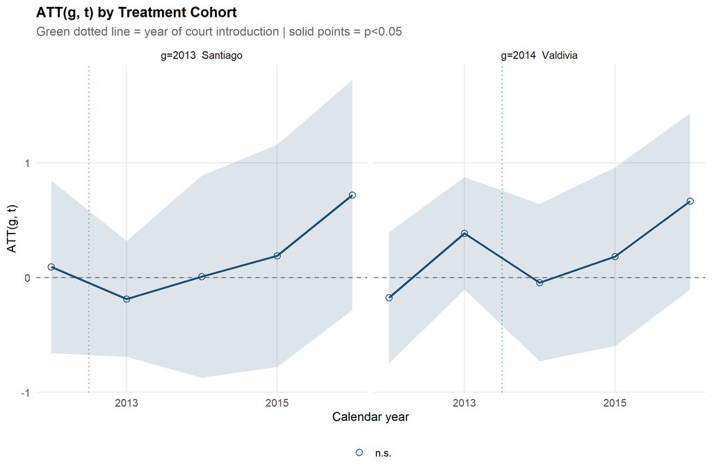

ATT(g,t) estimates for each cohort across calendar years. Dotted lines mark the year of court introduction.

```r
ggplot(att_gt_df, aes(t, att)) +
  geom_hline(yintercept = 0, linetype = "dashed", colour = "grey50") +
  geom_vline(aes(xintercept = g - 0.5), linetype = "dotted",
             colour = col_court, alpha = 0.8) +
  geom_ribbon(aes(ymin = ci_lo, ymax = ci_hi),
              fill = col_high, alpha = 0.15) +
  geom_line(colour = col_high, linewidth = 0.9) +
  geom_point(aes(shape = sig), colour = col_high, size = 2.5) +
  scale_shape_manual(values = c("p<0.05" = 19, "n.s." = 1)) +
  facet_wrap(~cohort, ncol = 2, scales = "free_x") +
  scale_x_continuous(breaks = seq(2011, 2024, 2)) +
  labs(
    title    = "ATT(g, t) by Treatment Cohort",
    subtitle = "Green dotted line = year of court introduction | solid points = p<0.05",
    x        = "Calendar year",
    y        = "ATT(g, t)",
    shape    = NULL
  ) +
  theme(legend.position = "bottom")
```

```r
ggsave(dout("fig5_att_gt_cohorts.png"), width = 10, height = 5, dpi = 150)
```